# Twitter Analytics Using R

## Part 3. Sentiment Analysis

Sentiment analyses classify communications as positive, negative, or neutral. Determining sentiment ranges from very simple classification methods to very complex algorithms. For ease and transparency in this example, we will classify the sentiment of a tweet based on the polarity of the individual words. Each word will be given a score of +1 if classified as positive, -1 if negative, and 0 if classified as neutral. This will be determined using positive and negative lexicon lists compiled by Minqing Hu and Bing Liu for their work “[Mining and Summarizing Customer Reviews](https://www.cs.uic.edu/~liub/FBS/sentiment-analysis.html)”. The total polarity score of a given tweet will result in adding together the scores of all the individual words. Once you go to the page, click on Opinion Lexicon and then download the rar file.

### Install and Load R Packages

```r
 # Install packages for sentiment analysis
if (!require(twitteR)) {install.packages("twitteR")}
if (!require(ROAuth)) {install.packages("ROAuth")}
if (!require(plyr)) {install.packages("plyr")}
if (!require(stringr)) {install.packages("stringr")}
if (!require(ggplot2)) {install.packages("ggplot2")}
library(twitteR)
library(ROAuth)
library(plyr)
library(dplyr)
library(stringr)
library(ggplot2)
```

### Authentication with OAuth

```r
# you must get the following information from the Twitter App you just created
my.consumer.key = "fH4IijcQUrwxEQ3mmb6G2gzUc"
my.consumer.secret = "FxkuV6ePyFaia2LmyxetoH50IxGrQcEYbwnLe3EjVDWsCdPrhJ"
my.access.token = "99989439-wG82y2hMmAmlJ1iIlQgNu0l65ZOKVuVscj4Idm9Xu"
my.access.token.secret = "QNehvUZOGNNZyqFYDCAP6tlWEHWIBbKIhiqPEKAM2SOoT"
my_oauth <- setup_twitter_oauth(consumer_key = my.consumer.key, consumer_secret = my.consumer.secret, access_token = my.access.token, access_secret = my.access.token.secret)
```

```
[1] "Using direct authentication"
```

```r
save(my_oauth, file = "my_oauth.Rdata")
```

### Read Positive and Negative Words

```r
neg = scan("negative-words.txt", what="character", comment.char=";")
```

```
Read 4783 items
```

```r
pos = scan("positive-words.txt", what="character", comment.char=";")
```

```
Read 2006 items
```

### Function for Scoring Tweets

```r
score.sentiment = function(tweets, pos.words, neg.words)
{
scores = laply(tweets, function(tweet, pos.words, neg.words) {
tweet = gsub('https://','',tweet) # removes https://
tweet = gsub('http://','',tweet) # removes http://
tweet=gsub('[^[:graph:]]', ' ',tweet) ## removes graphic characters  #like emoticons
tweet = gsub('[[:punct:]]', '', tweet) # removes punctuation
tweet = gsub('[[:cntrl:]]', '', tweet) # removes control characters
tweet = gsub('\\d+', '', tweet) # removes numbers
tweet=str_replace_all(tweet,"[^[:graph:]]", " ")
tweet = tolower(tweet) # makes all letters lowercase
word.list = str_split(tweet, '\\s+') # splits the tweets by word in a list

words = unlist(word.list) # turns the list into vector

pos.matches = match(words, pos.words) ## returns matching
          #values for words from list
neg.matches = match(words, neg.words)

pos.matches = !is.na(pos.matches) ## converts matching values to true of false
neg.matches = !is.na(neg.matches)

score = sum(pos.matches) - sum(neg.matches) # true and false are
                #treated as 1 and 0 so they can be added

return(score)

}, pos.words, neg.words )

scores.df = data.frame(score=scores, text=tweets)

return(scores.df)

}
```

### Extract Tweets

```r
tweets = searchTwitter('Trump',n=2500)
Tweets.text = laply(tweets,function(t)t$getText()) # gets text from Tweets
analysis = score.sentiment(Tweets.text, pos, neg) # calls sentiment function
```

### Plot Sentiment Scores

```r
table(analysis$score)
```

```
 -5  -4  -3  -2  -1   0   1   2   3   4   5
  1   2  55 121 406 597 826 295 181  14   2
```

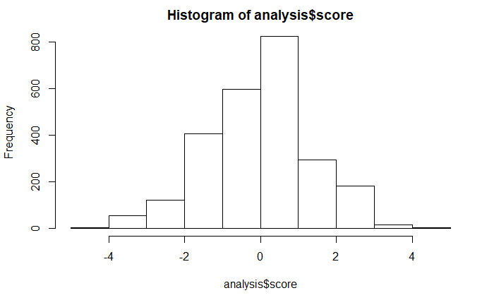

```r
hist(analysis$score)
```